# CaseStudy

Julia Walencik

2025-12-01

## Biblioteki

```r
library(class)
library(psych)
library(tidyverse)
library(caret)
library(CHAID)
library(randomForest)
```

# Wczytywanie danych oraz preprocesing

```r
SP <- read.table("StudentsPerformance.csv", header = TRUE, sep = ",")
head(SP)
```

```
##   gender race.ethnicity parental.level.of.education        lunch
## 1 female        group B           bachelor's degree     standard
## 2 female        group C                some college     standard
## 3 female        group B             master's degree     standard
## 4   male        group A          associate's degree free/reduced
## 5   male        group C                some college     standard
## 6 female        group B          associate's degree     standard
##   test.preparation.course math.score reading.score writing.score
## 1                    none         72            72            74
## 2               completed         69            90            88
## 3                    none         90            95            93
## 4                    none         47            57            44
## 5                    none         76            78            75
## 6                    none         71            83            78
```

```r
str(SP)
```

```
## 'data.frame':    1000 obs. of  8 variables:
##  $ gender                     : chr  "female" "female" "female" "male" ...
##  $ race.ethnicity             : chr  "group B" "group C" "group B" "group A" ...
##  $ parental.level.of.education: chr  "bachelor's degree" "some college" "master's degree" "associate's degree" ...
##  $ lunch                      : chr  "standard" "standard" "standard" "free/reduced" ...
##  $ test.preparation.course    : chr  "none" "completed" "none" "none" ...
##  $ math.score                 : int  72 69 90 47 76 71 88 40 64 38 ...
##  $ reading.score              : int  72 90 95 57 78 83 95 43 64 60 ...
##  $ writing.score              : int  74 88 93 44 75 78 92 39 67 50 ...
```

```r
summary(SP)
```

```
##     gender          race.ethnicity     parental.level.of.education
##  Length:1000        Length:1000        Length:1000
##  Class :character   Class :character   Class :character
##  Mode  :character   Mode  :character   Mode  :character
##
##
##
##     lunch           test.preparation.course   math.score     reading.score
##  Length:1000        Length:1000             Min.   :  0.00   Min.   : 17.00
##  Class :character   Class :character        1st Qu.: 57.00   1st Qu.: 59.00
##  Mode  :character   Mode  :character        Median : 66.00   Median : 70.00
##                                             Mean   : 66.09   Mean   : 69.17
##                                             3rd Qu.: 77.00   3rd Qu.: 79.00
##                                             Max.   :100.00   Max.   :100.00
##  writing.score
##  Min.   : 10.00
##  1st Qu.: 57.75
##  Median : 69.00
##  Mean   : 68.05
##  3rd Qu.: 79.00
##  Max.   :100.00
```

```r
for (i in 1:5){
  print(unique(SP[[i]]))
}
```

```
## [1] "female" "male"
## [1] "group B" "group C" "group A" "group D" "group E"
## [1] "bachelor's degree"  "some college"       "master's degree"
## [4] "associate's degree" "high school"        "some high school"
## [1] "standard"     "free/reduced"
## [1] "none"      "completed"
```

Dane zostały wczytane bez większych problemów. Zestaw danych jest kompletny, dane jakościowe są poprawne i nie zawierają literówek lub błędów, dane ilościowe są poprawne i nie zawierają wartości błędnych.

# Sprawdzenie korelacji

## zmiennych ilościowych oraz jakościowych.

Aby sprawdzić możliwe korelacje między zmiennymi jakościowymi a ilościowymi dokonano transformacji danych na format długi. Nie zostanie on użyty do modelu.

```r
cor(SP[6:8])
```

```
##               math.score reading.score writing.score
## math.score     1.0000000     0.8175797     0.8026420
## reading.score  0.8175797     1.0000000     0.9545981
## writing.score  0.8026420     0.9545981     1.0000000
```

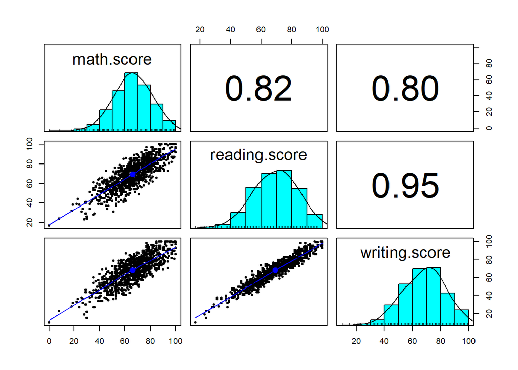

```r
pairs.panels(SP[6:8])
```

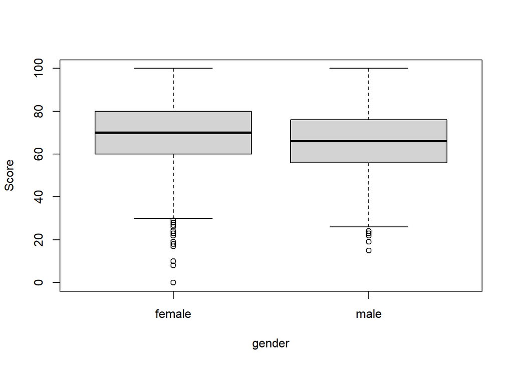

```r
SP_long <- tidyr::gather(SP, key = "Subject", value = "Score", c("math.score", "reading.score", "writing.score"))
boxplot(Score~gender, data = SP_long)
```

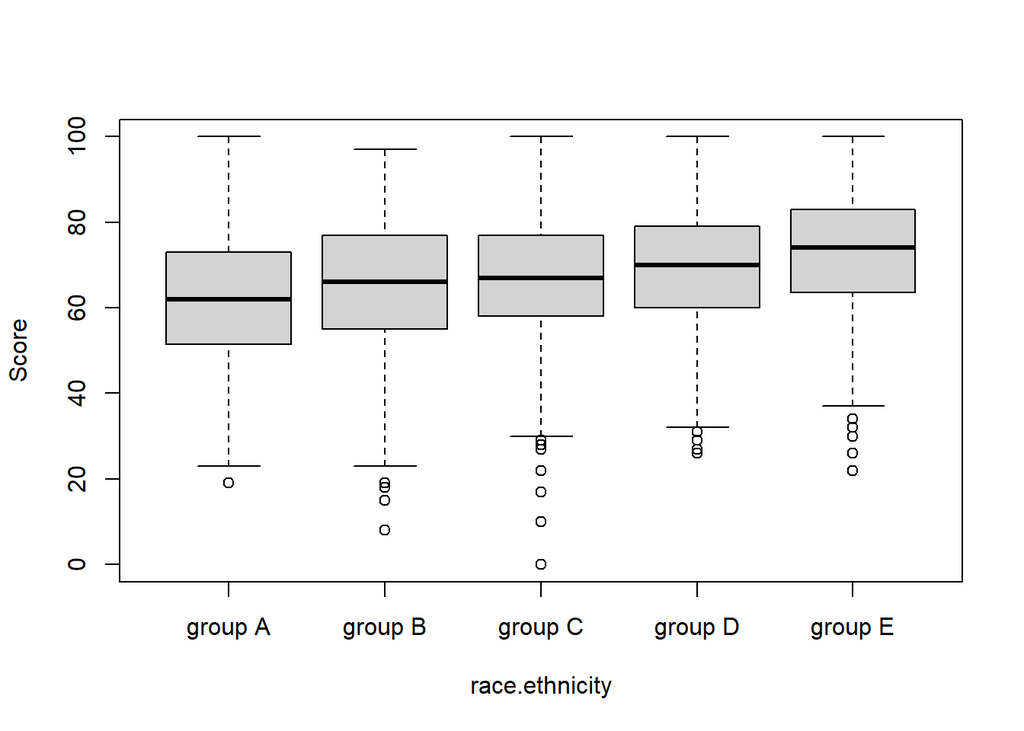

```r
boxplot(Score~race.ethnicity, data = SP_long)
```

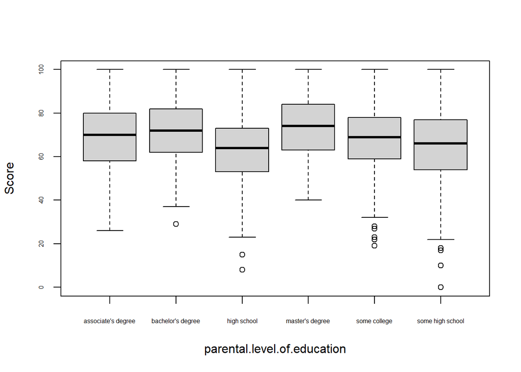

```r
boxplot(Score~parental.level.of.education, data = SP_long, cex.axis=0.5)
```

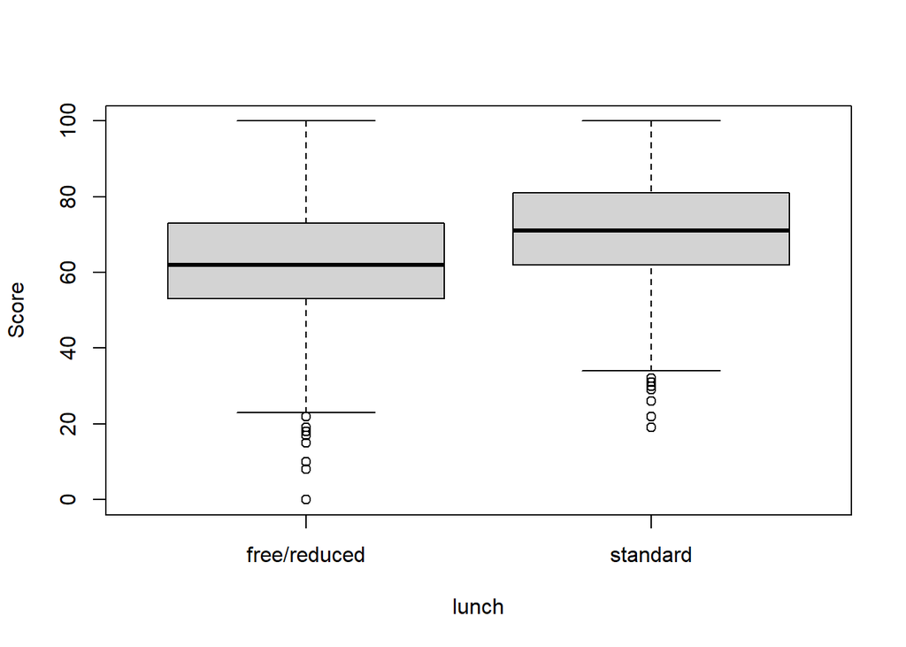

```r
boxplot(Score~lunch, data = SP_long)
```

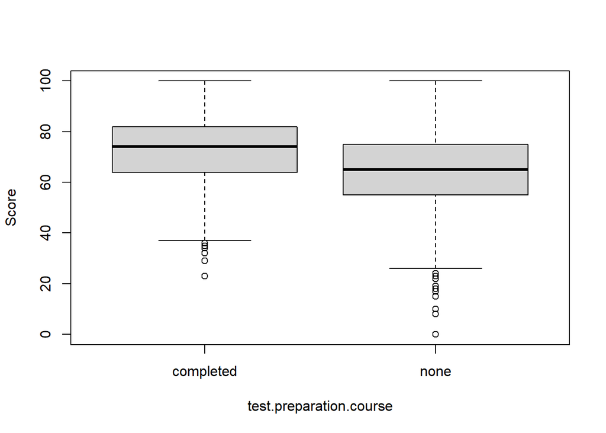

```r
boxplot(Score~test.preparation.course, data = SP_long)
```

Bardzo duża korelacja między zmiennymi ilościowymi. Oznacza to, że uczniowie osiągający wysokie wyniki w jednym przedmiocie uzyskują również wysokie wyniki w pozostałych.

Rozkład wyników ze względu na `gender` jest bardzo zbliżony, z różnicą większej ilości wartości odstających u kobiet.

Analogiczna sytuacja ma miejsce dla `race.ethnicity` oraz `parental.level.of.education`. Widoczne są niewielkie różnice pomiędzy grupami, lecz żadna grupa nie odbiega znacząco od pozostałych.

W przypadku zmiennych `lunch` i `test.preparation.course` rozkład wartości `Score` delikatnie różni się między kategoriami. W przypadku `lunch`:`free/reduced` oraz `test.preparation.course`:`none` rozkład ma mniejszą średnią oraz wartości centralne. Rozkłady dla tych kategorii mają też bardziej oddalone wartości odstające (Studenci osiągają najniższe wyniki tylko dla tych podgrup).

Przez brak istotnych różnic w rozkładach między kategoriami zmiennych jakościowych może oznaczać, że zmienne te nie będą bardzo istotne w klasyfikacji.

# Przygotowanie danych

## do klasyfikacji

Zmienną klasyfikowaną będzie zmienna `Mark`, która jest przypisywana na podstawie średniej wyników.

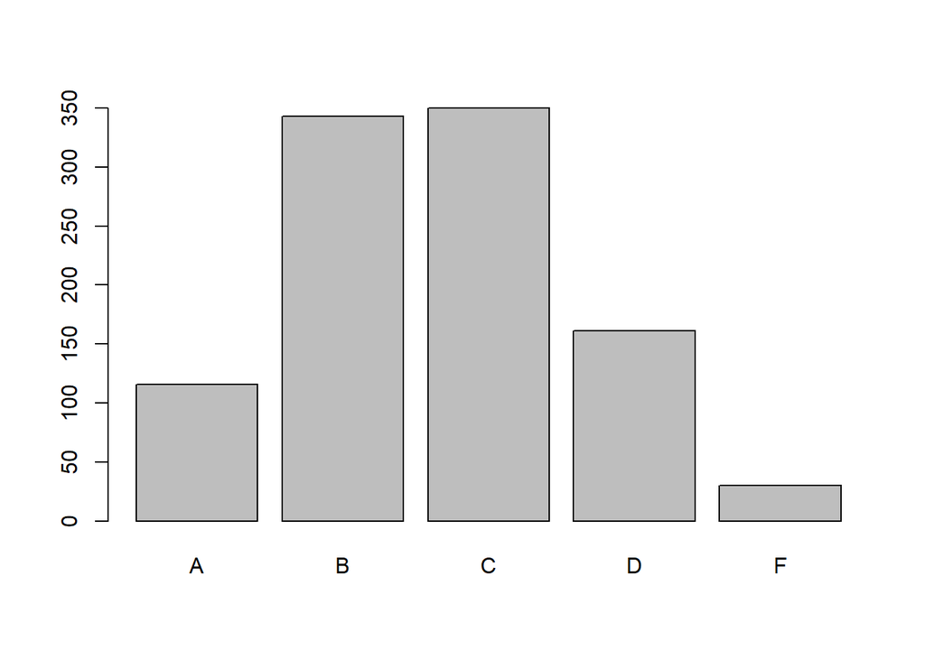

```r
SP_class <- SP %>%
  mutate(final.score = (reading.score+writing.score+math.score)/3) %>%
  mutate(Mark = ifelse(final.score>=85, 'A', # Score: 85-100
                ifelse(final.score>=70, 'B', # Score: 70-84
                ifelse(final.score>=55, 'C', # Score: 55-69
                ifelse(final.score>=40, 'D', # Score: 40-54
                'F') # Score: 00-39
                ))))%>%
  select(!final.score)

barplot(table(SP_class$Mark))
```

Drzewo decyzyjne CHAID wymaga uprzedniej faktoryzacji zmiennych. Faktoryzacja w przypadku zmiennych jakościowych jest bardzo prosta.

```r
SP_class$lunch <- factor(SP_class$lunch)
SP_class$gender <- factor(SP_class$gender)
SP_class$race.ethnicity <- factor(SP_class$race.ethnicity)
SP_class$Mark <- factor(SP_class$Mark, levels = c("A","B","C","D","F"), ordered = TRUE)
SP_class$test.preparation.course <- factor(SP_class$test.preparation.course)
SP_class$parental.level.of.education <- factor(SP_class$parental.level.of.education)
```

Dla zmiennych ilościowych faktoryzacja musi być wykonana poprzez podziął zakresu wartości i przypisanie wyników do odpowiedniej kategorii. Da nam to zmienne sfaktoryzowane, które można użyć do modelu CHAID. Strona, która zainspirowała to podejście: https://www.r-bloggers.com/2018/05/chaid-and-r-when-you-need-explanation-may-15-2018/

```r
SP_class_int <- SP_class %>%
  mutate(
    math.score.int    = cut_interval(math.score, n = 5),
    reading.score.int = cut_interval(reading.score, n = 5),
    writing.score.int = cut_interval(writing.score, n = 5)) %>%
  select(-c(math.score, reading.score, writing.score))

str(SP_class_int)
```

```
## 'data.frame':    1000 obs. of  9 variables:
##  $ gender                     : Factor w/ 2 levels "female","male": 1 1 1 2 2 1 1 2 2 1 ...
##  $ race.ethnicity             : Factor w/ 5 levels "group A","group B",..: 2 3 2 1 3 2 2 2 4 2 ...
##  $ parental.level.of.education: Factor w/ 6 levels "associate's degree",..: 2 5 4 1 5 1 5 5 3 3 ...
##  $ lunch                      : Factor w/ 2 levels "free/reduced",..: 2 2 2 1 2 2 2 1 1 1 ...
##  $ test.preparation.course    : Factor w/ 2 levels "completed","none": 2 1 2 2 2 2 1 2 1 2 ...
##  $ Mark                       : Ord.factor w/ 5 levels "A"<"B"<"C"<"D"<..: 2 2 1 4 2 2 1 4 3 4 ...
##  $ math.score.int             : Factor w/ 5 levels "[0,20]","(20,40]",..: 4 4 5 3 4 4 5 2 4 2 ...
##  $ reading.score.int          : Factor w/ 5 levels "[17,33.6]","(33.6,50.2]",..: 4 5 5 3 4 4 5 2 3 3 ...
##  $ writing.score.int          : Factor w/ 5 levels "[10,28]","(28,46]",..: 4 5 5 2 4 4 5 2 4 3 ...
```

```r
for (i in 1:9){
  print(unique(SP_class_int[[i]]))
}
```

```
## [1] female male
## Levels: female male
## [1] group B group C group A group D group E
## Levels: group A group B group C group D group E
## [1] bachelor's degree  some college       master's degree    associate's degree
## [5] high school        some high school
## 6 Levels: associate's degree bachelor's degree high school ... some high school
## [1] standard     free/reduced
## Levels: free/reduced standard
## [1] none      completed
## Levels: completed none
## [1] B A D C F
## Levels: A < B < C < D < F
## [1] (60,80]  (80,100] (40,60]  (20,40]  [0,20]
## Levels: [0,20] (20,40] (40,60] (60,80] (80,100]
## [1] (66.8,83.4] (83.4,100]  (50.2,66.8] (33.6,50.2] [17,33.6]
## Levels: [17,33.6] (33.6,50.2] (50.2,66.8] (66.8,83.4] (83.4,100]
## [1] (64,82]  (82,100] (28,46]  (46,64]  [10,28]
## Levels: [10,28] (28,46] (46,64] (64,82] (82,100]
```

# Stworzenie modelu

## opartego na drzewie decyzyjnym CHAID

### Podział na podzbiory: treningowy i testowy

```r
set.seed(42)
train_index <- createDataPartition(SP_class_int$Mark, p = 0.7, list = FALSE)
SP_train <- SP_class_int[train_index, ]
SP_test  <- SP_class_int[-train_index, ]
```

### Model

```r
ctrl <- chaid_control(minsplit = 20, minbucket = 7, alpha2 = 0.05, alpha4 = 0.05, maxheight = 5)

model_chaid <- chaid(Mark~., data = SP_train, control = ctrl)
model_chaid
```

```
##
## Model formula:
## Mark ~ gender + race.ethnicity + parental.level.of.education +
##     lunch + test.preparation.course + math.score.int + reading.score.int +
##     writing.score.int
##
## Fitted party:
## [1] root
## |   [2] reading.score.int in [17,33.6]: F (n = 9, err = 0.0%)
## |   [3] reading.score.int in (33.6,50.2]
## |   |   [4] math.score.int in [0,20], (20,40], (80,100]: F (n = 16, err = 43.8%)
## |   |   [5] math.score.int in (40,60], (60,80]: D (n = 43, err = 7.0%)
## |   [6] reading.score.int in (50.2,66.8]
## |   |   [7] math.score.int in [0,20], (20,40]: D (n = 12, err = 8.3%)
## |   |   [8] math.score.int in (40,60]
## |   |   |   [9] writing.score.int in [10,28], (28,46], (82,100]: D (n = 8, err = 0.0%)
## |   |   |   [10] writing.score.int in (46,64]: D (n = 91, err = 49.5%)
## |   |   |   [11] writing.score.int in (64,82]: C (n = 18, err = 0.0%)
## |   |   [12] math.score.int in (60,80], (80,100]: C (n = 96, err = 4.2%)
## |   [13] reading.score.int in (66.8,83.4]
## |   |   [14] math.score.int in [0,20], (20,40], (40,60]
## |   |   |   [15] test.preparation.course in completed: C (n = 17, err = 29.4%)
## |   |   |   [16] test.preparation.course in none: C (n = 24, err = 0.0%)
## |   |   [17] math.score.int in (60,80]
## |   |   |   [18] writing.score.int in [10,28], (28,46], (46,64]: C (n = 15, err = 6.7%)
## |   |   |   [19] writing.score.int in (64,82], (82,100]
## |   |   |   |   [20] lunch in free/reduced: B (n = 58, err = 29.3%)
## |   |   |   |   [21] lunch in standard: B (n = 132, err = 16.7%)
## |   |   [22] math.score.int in (80,100]: B (n = 39, err = 5.1%)
## |   [23] reading.score.int in (83.4,100]
## |   |   [24] math.score.int in [0,20], (20,40], (40,60], (60,80]
## |   |   |   [25] writing.score.int in [10,28], (28,46], (46,64], (64,82]: B (n = 11, err = 0.0%)
## |   |   |   [26] writing.score.int in (82,100]: B (n = 35, err = 37.1%)
## |   |   [27] math.score.int in (80,100]
## |   |   |   [28] writing.score.int in [10,28], (28,46], (46,64], (64,82]: A (n = 18, err = 50.0%)
## |   |   |   [29] writing.score.int in (82,100]: A (n = 60, err = 3.3%)
##
## Number of inner nodes:    11
## Number of terminal nodes: 18
```

[figure not shown]

```r
plot(model_chaid, gp = gpar(fontsize = 5))
```

Najbardziej przydatnymi zmiennymi są wyniki poszczególnych przedmiotów, są używane najczęściej, co nie jest to niespodziewane. Na niższych węzłach pojawiają się `test.preparation.course` i `lunch`. Co oznacza, że te zmienne są o wiele mniej ważne, ale w jakimś stopniu użyteczne.

### Predykcja i ocena modelu

```r
pred_chaid <- predict(model_chaid, newdata = SP_test)
confusionMatrix(pred_chaid, SP_test$Mark)
```

```
## Confusion Matrix and Statistics
##
##           Reference
## Prediction  A  B  C  D  F
##          A 29  5  0  0  0
##          B  5 94 18  0  0
##          C  0  3 65  0  0
##          D  0  0 22 45  2
##          F  0  0  0  3  7
##
## Overall Statistics
##
##                Accuracy : 0.8054
##                  95% CI : (0.7558, 0.8488)
##     No Information Rate : 0.3523
##     P-Value [Acc > NIR] : < 2.2e-16
##
##                   Kappa : 0.7348
##
##  Mcnemar's Test P-Value : NA
##
## Statistics by Class:
##
##                      Class: A Class: B Class: C Class: D Class: F
## Sensitivity           0.85294   0.9216   0.6190   0.9375  0.77778
## Specificity           0.98106   0.8827   0.9845   0.9040  0.98962
## Pos Pred Value        0.85294   0.8034   0.9559   0.6522  0.70000
## Neg Pred Value        0.98106   0.9558   0.8261   0.9869  0.99306
## Prevalence            0.11409   0.3423   0.3523   0.1611  0.03020
## Detection Rate        0.09732   0.3154   0.2181   0.1510  0.02349
## Detection Prevalence  0.11409   0.3926   0.2282   0.2315  0.03356
## Balanced Accuracy     0.91700   0.9021   0.8018   0.9207  0.88370
```

Accuracy : 0.8054. Bardzo dobry wynik. Model dobrze radzi sobie z rozpoznawaniem klas oraz w dużej większości przypadków poprawnie przewiduje wartości. Największe problemy zdaje się mieć z klasą **C**: `Sensitivity` - 0.6190.

# Random Forest

Random Forest - ten model nie wymaga zmiennych sfaktoryzowanych, dlatego zostanie użyty zestaw danych z oryginalnymi zmiennymi ilościowymi: `SP_class`.

### Podział na podzbiory: treningowy i testowy

```r
SP_train2 <- SP_class[train_index, ]
SP_test2 <- SP_class[-train_index, ]
```

### Model

```r
rf_model <- randomForest(Mark~., data = SP_train2)
print(rf_model)
```

```
##
## Call:
##  randomForest(formula = Mark ~ ., data = SP_train2)
##                Type of random forest: classification
##                      Number of trees: 500
## No. of variables tried at each split: 2
##
##         OOB estimate of  error rate: 5.56%
## Confusion matrix:
##    A   B   C   D  F class.error
## A 74   8   0   0  0  0.09756098
## B  2 229  10   0  0  0.04979253
## C  0   9 234   2  0  0.04489796
## D  0   0   5 108  0  0.04424779
## F  0   0   0   3 18  0.14285714
```

### Predykcja i ocena modelu

```r
pred_rf <- predict(rf_model, SP_test2)
confusionMatrix(pred_rf, SP_test2$Mark)
```

```
## Confusion Matrix and Statistics
##
##           Reference
## Prediction   A   B   C   D   F
##          A  30   0   0   0   0
##          B   4  99   2   0   0
##          C   0   3 103   3   0
##          D   0   0   0  45   2
##          F   0   0   0   0   7
##
## Overall Statistics
##
##                Accuracy : 0.953
##                  95% CI : (0.9224, 0.9741)
##     No Information Rate : 0.3523
##     P-Value [Acc > NIR] : < 2.2e-16
##
##                   Kappa : 0.9341
##
##  Mcnemar's Test P-Value : NA
##
## Statistics by Class:
##
##                      Class: A Class: B Class: C Class: D Class: F
## Sensitivity            0.8824   0.9706   0.9810   0.9375  0.77778
## Specificity            1.0000   0.9694   0.9689   0.9920  1.00000
## Pos Pred Value         1.0000   0.9429   0.9450   0.9574  1.00000
## Neg Pred Value         0.9851   0.9845   0.9894   0.9880  0.99313
## Prevalence             0.1141   0.3423   0.3523   0.1611  0.03020
## Detection Rate         0.1007   0.3322   0.3456   0.1510  0.02349
## Detection Prevalence   0.1007   0.3523   0.3658   0.1577  0.02349
## Balanced Accuracy      0.9412   0.9700   0.9749   0.9647  0.88889
```

```r
importance(rf_model)
```

```
##                             MeanDecreaseGini
## gender                              8.626849
## race.ethnicity                     12.601860
## parental.level.of.education        16.002323
## lunch                               5.871551
## test.preparation.course             6.028630
## math.score                        116.936008
## reading.score                     163.059800
## writing.score                     160.285950
```

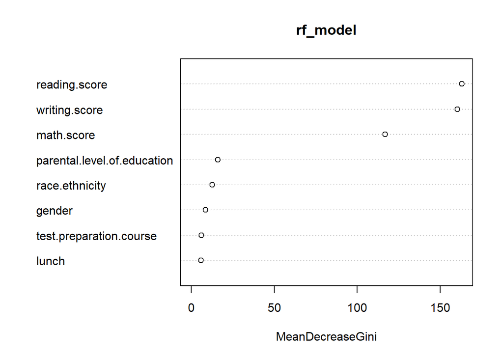

```r
varImpPlot(rf_model)
```

Accuracy : 0.953. Model jest niemalże idealny, znakomicie rozdziela klasy. Na wykresie widać, że najważniejsze zmienne to `writng.score` oraz `readin.score`. Ważną zmienną jest też `math.score`. Pozostałe zmienne są nieznaczące.

Zaskakujące jest, że `lunch` oraz `test.preparation.course` są najmniej ważne. Po wykresie boxplot wykonanym powyżej sądzono, że będą one najbardziej przydatne ze zmiennych jakościowych.

# Podsumowanie

### Końcowe wnioski

**Model CHAID** bardzo dobrze sprawdza się w przewidywaniu, jednak wymaga faktoryzacji cech, w tym przekształcenia zmiennych ilościowych na przedziały wartości. Może to powodować nieznaczną utratę informacji, gdyż zamiast dokładnych wartości wykorzystywane są przedziały.

Wydaje się to potwierdzać model drzewa decyzyjnego **Forest Random**, który pracując na danych ilościowych osiągnął o wiele lepsze rezultaty. Z tego powodu model CHAID może nie być idealny, lecz wciąż sprawdza się bardzo dobrze.